# Data set Pathway and Network Analysis

BCB420H1 - Assignment 3

Jun Ni Du

April 4, 2023

## 0.1 Report Set-up

Load all required packages for this report and define some global customization settings.

```r
# for knitting the .rmd file to .html
if (! requireNamespace("knitr", quietly = TRUE)) {
  install.packages("knitr")
}
if (! requireNamespace("kableExtra", quietly = TRUE)) {
  install.packages("kableExtra")
}

# for creating models and analyzing expression data
if (! requireNamespace("edgeR", quietly = TRUE)) {
  BiocManager::install("edgeR")
}
if (! requireNamespace("limma", quietly = TRUE)) {
  BiocManager::install("limma")
}
if (! requireNamespace("dplyr", quietly = TRUE)) {
  install.packages("dplyr")
}
if (! requireNamespace("gprofiler2", quietly = TRUE)) {
  install.packages("gprofiler2")
}

# for creating plots
if (! requireNamespace("ggplot2", quietly = TRUE)) {
  install.packages("ggplot2")
}
if (! requireNamespace("ggrepel", quietly = TRUE)) {
  install.packages("ggrepel")
}
if (! requireNamespace("ComplexHeatmap", quietly = TRUE)) {
  BiocManager::install("ComplexHeatmap")
}
if (! requireNamespace("circlize", quietly = TRUE)) {
  BiocManager::install("circlize")
}
if (! requireNamespace("fgsea", quietly = TRUE)) {
  BiocManager::install("fgsea")
}
if (! requireNamespace("qusage", quietly = TRUE)) {
  BiocManager::install("qusage")
}
if (! requireNamespace("clusterProfiler", quietly = TRUE)) {
  BiocManager::install("clusterProfiler")
}
if (! requireNamespace("org.Hs.eg.db", quietly = TRUE)) {
  BiocManager::install("org.Hs.eg.db")
}

library(clusterProfiler)
library(org.Hs.eg.db)
library(edgeR)
library(dplyr)
library(ggplot2)
library(fgsea)
library(qusage)

# wraps lines that are too long
knitr::opts_chunk$set(tidy.opts=list(width.cutoff=80), tidy=TRUE)
# set default behaviors for all chunks
knitr::opts_chunk$set(warning = FALSE, message = FALSE)
```

All table and figure outputs in this report are rendered using the knitr package [1], and kableExtra package [2] for styling. Some codes in this report are adapted from Lecture 10 - GSEA.

# 1 Introduction

## 1.1 Background on the Data Set

Glucocorticoids (GC) is a class of steroid hormones that plays a role in regulating the immune system and certain aspects of the immune function, such as inflammation. The most common naturally-produced GC hormone in humans is cortisol, which are produced by the adrenal glands. Due to GC’s potent anti-inflammatory effects, several synthetic forms of GC are used as immunosuppressive drugs to treat various medical conditions such as asthma, allergies, autoimmune disorders, and cancer. [3]

The data set used in this report comes from Quatrini et al. (2022)’s paper: **Glucocorticoids inhibit human hematopoietic stem cell differentiation toward a common ILC precursor** [3], where they analyzed the the role of GC on regulating innate lymphoid cells (ILCs) differentiation, including cytotoxic natural killer cells and helper ILCs, from human hematopoietic stem cells (HSCs). The RNA-seq data set used in this report is a part of the overall study; it evaluates the effect of the presence of Dexamethasone (DEX), a glucocorticoid medication, on gene expressions of HSCs. The raw data set is downloaded from the NCBI Gene Expression Omnibus, with ID [**GSE186950**](https://www.ncbi.nlm.nih.gov/geo/query/acc.cgi?acc=GSE186950). [4]

## 1.2 Recap of Assignment #1 and #2

In [Assignment 1](https://github.com/bcb420-2023/JunNi_Du/blob/main/a1.Rmd), I performed initial pre-processing and normalization of the data set. The raw data set contains 2 groups, control and conditioned (DEX), with 3 samples in each group: AF25, AF26, AF29. The data set initially contained gene expressions of 58683 genes, but 46243 genes were removed due to low counts with less than 1 count per million in at least 3 samples, leaving 12440 genes.

In the original data set, genes are labeled in a mix of HUGO gene symbols, GenBank accession IDs, EMBL identifiers, etc. Using the biomaRt package [5], we attempted to map non-HUGO identifiers to their corresponding HUGO gene symbols, but had to discard 847 (6.8%) genes with no matches, leaving a final set of 11593 unique genes.

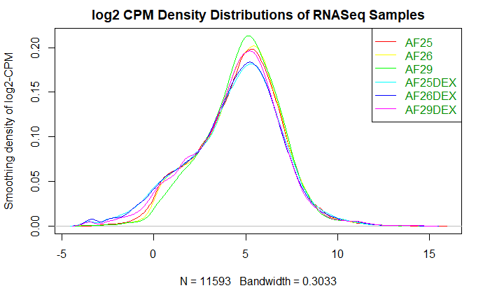

```r
knitr::include_graphics("figures/A2/raw_fltr_data_cpm.png")
```

**Figure 1.** *log2 CPM Distributions of gene expressions of each sample in the data set, after filtering out genes with low-counts or without HUGO gene symbol match, and before TMM normalization. This figure is adapted from Assignment 1 with slight aesthetic modifications.*

As shown in Fig.1, The filtered data set is approximately normally distributed with no outlier samples, and therefore we normalized the data using the Trimmed Mean of M-values (TMM) method, via the edgeR package. [6]

In [Assignment 2](https://github.com/bcb420-2023/JunNi_Du/blob/main/A2_JunNi_Du.Rmd), using the normalized data set, we built two models to identify the set of significantly differentially expressed genes. Then, we selected one of the models (a treatment-only model built using the exact test of the edgeR package) and performed thresholded over-representation analysis on genes that are significantly differentially expressed, based on a threshold of FDR-correct p-value < 0.05.

In this assignment, we’ll start with the result from the treatment-only exact test model and load it as an .rds file. The `top_et.rds` file can be generated by running `saveRDS(top_et, 'top_et.rds')` after running all code chunks in A2_JunNi_Du.Rmd.

```r
top_et <- readRDS("top_et.rds")
et_output <- top_et$table

# calculate rank for each gene
et_output[, "rank"] <- -log(et_output$PValue, base = 10) * sign(et_output$logFC)
et_output <- et_output[order(et_output$rank), ]
```

# 2 Non-thresholded Gene set Enrichment Analysis

```r
rnk <- data.frame(rownames(et_output), et_output$rank)
colnames(rnk) <- c("GeneName", "rank")
write.table(rnk, file = "./dex_ctrl.rnk", sep = "\t", col.name = TRUE, row.names = FALSE,
    quote = FALSE)
```

```r
gsea_upreg <- read.table(file = "gsea_report_for_na_pos_1680460999801.tsv", sep = "\t",
    header = TRUE, fill = TRUE)
gsea_downreg <- read.table(file = "gsea_report_for_na_neg_1680460999801.tsv", sep = "\t",
    header = TRUE, fill = TRUE)
```

## 2.1 Non-thresholded Gene set Enrichment Analysis Questions

**2. Summarize your enrichment results.**

The GSEA pre-ranked identified 2590 up-regulated gene sets out of 5263 total gene sets, with 327 gene sets having nominal p-value < 0.05 and 1 gene set having FDR q-value < 0.25, which indicates significant enrichment.

For down-regulated gene sets, 2673 down-regulated gene sets out of 5263 total gene sets were identified, with 345 gene sets having nominal p-value < 0.05 and 62 gene set having FDR q-value < 0.25, which indicates significant enrichment.

```r
pathway_names <- sapply(stringr::str_split(gsea_upreg$NAME, "%"), "[", 1:2)
pathway_names <- t(pathway_names)
gsea_upreg <- cbind(pathway_names, gsea_upreg)

upreg <- gsea_upreg[, c("1", "2", "SIZE", "NES", "NOM.p.val", "FDR.q.val")]
colnames(upreg) <- c("Term", "Data Source", "Size", "Normalized Enrichment Score",
    "Nominal p-value", "FDR q-value")
kableExtra::kable_paper(knitr::kable(head(upreg[which(upreg$"Nominal p-value" < 0.05),
    ]), format = "html", digits = 10))
```

| Term | Data Source | Size | Normalized Enrichment Score | Nominal p-value | FDR q-value |
| --- | --- | --- | --- | --- | --- |
| NEUTROPHIL DEGRANULATION | REACTOME DATABASE ID RELEASE 83 | 418 | 2.066326 | 0 | 0.3181236 |
| OXIDATIVE PHOSPHORYLATION | GOBP | 93 | 2.066148 | 0 | 0.1602628 |
| RESPIRATORY ELECTRON TRANSPORT, ATP SYNTHESIS BY CHEMIOSMOTIC COUPLING, AND HEAT PRODUCTION BY UNCOUPLING PROTEINS. | REACTOME | 117 | 2.007220 | 0 | 0.4715452 |
| RESPIRATORY ELECTRON TRANSPORT | REACTOME DATABASE ID RELEASE 83 | 97 | 1.996420 | 0 | 0.4438916 |
| HALLMARK_OXIDATIVE_PHOSPHORYLATION | MSIGDBHALLMARK | 149 | 1.993352 | 0 | 0.3759924 |
| THE CITRIC ACID (TCA) CYCLE AND RESPIRATORY ELECTRON TRANSPORT | REACTOME | 161 | 1.968398 | 0 | 0.4876496 |

```r
pathway_names <- sapply(stringr::str_split(gsea_downreg$NAME, "%"), "[", 1:2)
pathway_names <- t(pathway_names)
gsea_downreg <- cbind(pathway_names, gsea_downreg)

downreg <- gsea_downreg[, c("1", "2", "SIZE", "NES", "NOM.p.val", "FDR.q.val")]
colnames(downreg) <- c("Term", "Data Source", "Size", "Normalized Enrichment Score",
    "Nominal p-value", "FDR q-value")
kableExtra::kable_paper(knitr::kable(head(downreg[which(downreg$"Nominal p-value" <
    0.05), ]), format = "html", digits = 10))
```

| Term | Data Source | Size | Normalized Enrichment Score | Nominal p-value | FDR q-value |
| --- | --- | --- | --- | --- | --- |
| HALLMARK_INTERFERON_ALPHA_RESPONSE | MSIGDBHALLMARK | 71 | -2.064144 | 0.000000000 | 0.000000000 |
| T CELL ACTIVATION | GOBP | 121 | -1.970077 | 0.000000000 | 0.009179046 |
| INTERFERON ALPHA BETA SIGNALING | REACTOME | 50 | -1.921399 | 0.001811594 | 0.033516850 |
| HALLMARK_INTERFERON_GAMMA_RESPONSE | MSIGDBHALLMARK | 144 | -1.895172 | 0.000000000 | 0.057725385 |
| POSITIVE REGULATION OF SMALL GTPASE MEDIATED SIGNAL TRANSDUCTION | GOBP | 39 | -1.847791 | 0.000000000 | 0.175786400 |
| LYMPHOCYTE ACTIVATION | GOBP | 201 | -1.846445 | 0.000000000 | 0.150864050 |

**3. How do these results compare to the results from the thresholded analysis in Assignment #2. Compare qualitatively. Is this a straight forward comparison? Why or why not?**

```r
summary_A2 <- readRDS("summary_A2.rds")

upreg_comparison <- data.frame(summary_A2$`top_terms_up-reg`, tolower(upreg$Term[1:8]))
downreg_comparison <- data.frame(summary_A2$`top_terms_down-reg`, tolower(downreg$Term[1:8]))
colnames(upreg_comparison) <- c("A#2 ORA Top Terms (Up-Regulated)", "A#3 GSEA Top Terms (Up-Regulated)")
colnames(downreg_comparison) <- c("A#2 ORA Top Terms (Down-Regulated)", "A#3 GSEA Top Terms (Down-Regulated)")
kableExtra::kable_paper(knitr::kable(upreg_comparison, format = "html", digits = 10))
```

| A#2 ORA Top Terms (Up-Regulated) | A#3 GSEA Top Terms (Up-Regulated) |
| --- | --- |
| inflammatory response | neutrophil degranulation |
| cell migration | oxidative phosphorylation |
| Metabolic pathways | respiratory electron transport, atp synthesis by chemiosmotic coupling, and heat production by uncoupling proteins. |
| Amino sugar and nucleotide sugar metabolism | respiratory electron transport |
| Neutrophil degranulation | hallmark_oxidative_phosphorylation |
| Innate Immune System | the citric acid (tca) cycle and respiratory electron transport |
| Nuclear receptors meta-pathway | respiratory electron transport chain |
| Glucocorticoid receptor pathway | atp synthesis coupled electron transport |

```r
kableExtra::kable_paper(knitr::kable(downreg_comparison, format = "html", digits = 10))
```

| A#2 ORA Top Terms (Down-Regulated) | A#3 GSEA Top Terms (Down-Regulated) |
| --- | --- |
| signaling | hallmark_interferon_alpha_response |
| cell communication | t cell activation |
| Hematopoietic cell lineage | interferon alpha beta signaling |
| Asthma | hallmark_interferon_gamma_response |
| Cytokine Signaling in Immune system | positive regulation of small gtpase mediated signal transduction |
| Signal Transduction | lymphocyte activation |
| Pathogenesis of SARS-CoV-2 mediated by nsp9-nsp10 complex | antigen processing and presentation of exogenous antigen |
| T-cell receptor signaling pathway | antigen processing and presentation |